# 08_A_Benchmark_Methods_FittedVals

# References

1. Hyndman, R.J., & Athanasopoulos, G., 2021. *Forecasting: principles and practice*. 3rd edition.
2. Fable package documentation
- [Link to Fable Homepage](https://fable.tidyverts.org/index.html)
- [Link to Fable Article](https://fable.tidyverts.org/articles/fable.html)

# Libraries

```r
library(fpp3)
```

# Introduction

In this session we are going to:

- Explore some **benchmark models**. These are simple models that serve as the performance baseline against which we will compare more complex models.
  - If more complex models do not outperform these benchmarks, their complexity will not be justified.
- Introduce the concept of **fitted values** and compare them to forecasts.
- Practice the **basic steps behind fitting models and forecasting with the library `fable`.**
- Do some exercises.

For most of the simple examples in this notebook we will work with this time series studying the production of bricks between 1970 and 2004:

```r
bricks <- aus_production |>
  filter_index("1970 Q1" ~ "2004 Q4") |>
  select(Bricks)

head(bricks)
```

```
# A tsibble: 6 x 2 [1Q]
  Bricks Quarter
   <dbl>   <qtr>
1    386 1970 Q1
2    428 1970 Q2
3    434 1970 Q3
4    417 1970 Q4
5    385 1971 Q1
6    433 1971 Q2
```

# Fitted values vs forecasts

Before using a model, we need to **fit** it (classic statistics terminology), also known as **training** it (machine learning terminology). Fitting a model means using data to produce estimates of its parameters. We call this data the **training data**.

Note **a few important technical details**:

- We talk about **estimates of the parameters** because we are estimating them from a particular sample, or in our case, from a particular realization of the time series.
  - **Notation:**
    - $\beta$ - true value of the parameter.
    - $\hat{\beta}$ - estimate of the parameter.
  - We will often abuse this notation and write $\beta$ instead of $\hat{\beta}$, but know that, when fitting a model, we are producing estimates of the parameters.
- If we fitted the model to another sample or to another realization of the time series (think of this as repeating an experiment), we would produce different estimates of those parameters.
- Being estimates, those parameters have associated standard errors.

## Fitted values - example with linear regression

Let us use your knowledge of linear regression to illustrate the concept of fitted values. When fitting a linear regression model to predict a variable $y$ based on the values of a predictor $x$, we take a sample of data (our training data) and produce estimates of the model parameters.

Once these estimates $\hat{\beta_0}$ and $\hat{\beta_1}$ have been produced, we can compute the values of $y$ predicted by the model for the specific values of $x$ of the training data. **The values of $y$ returned by the model are the fitted values $\hat{y_t}$ of the linear regression model**.

At each point there is a difference between the actual value of the training data $y$ and the fitted value $\hat{y_t}$. This is what we call the **random error**. The word error here should not be understood as *mistake*, but rather as *anything that may affect $y_t$ other than the linear effect of $x_t$*.

$$y_t - \hat{y_t} = \varepsilon_t$$

The image below illustrates this:

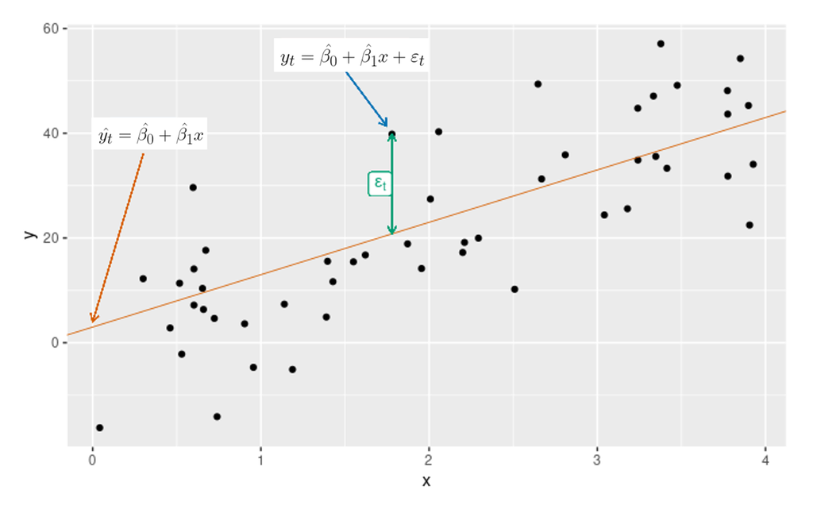

## Time Series case - Fitted values and forecasts

The following figure clarifies the difference between **fitted values** and **forecasts**. It summarizes the forecasting task and is relevant for both this course and the next:

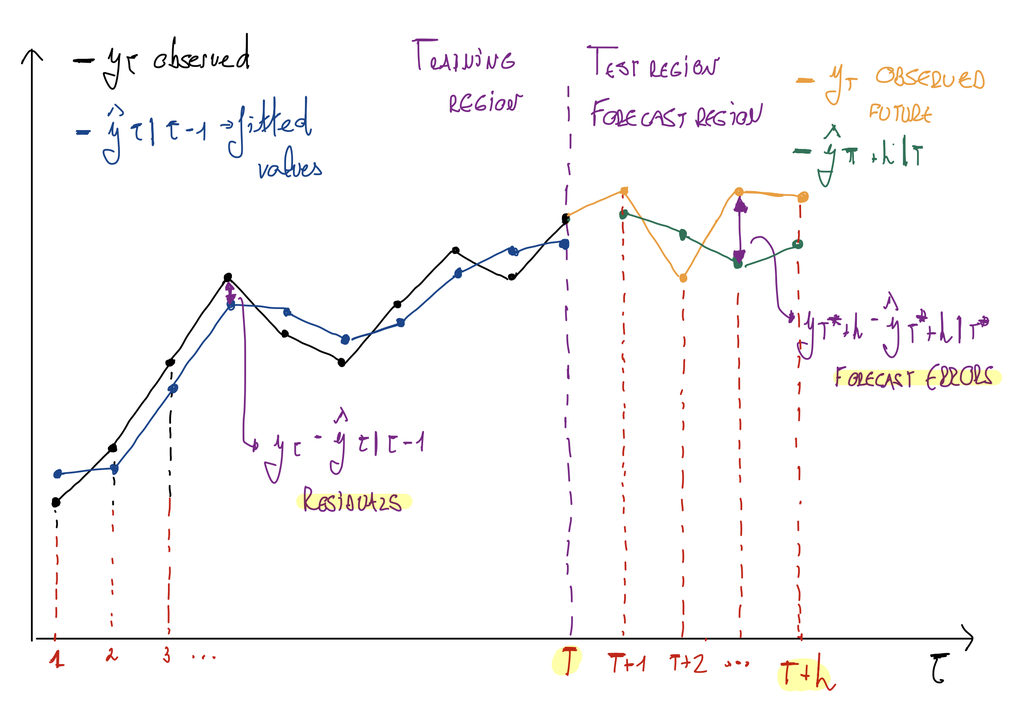

In this figure:

- The black dots represent the **available observations at the time of forecasting** $y_t$. These extend from $t=1$ to $t=T$.
- The blue dots represent the **fitted values**, the values returned by the model we fitted in the training region.
  - These fitted values are defined as *one-step-ahead forecasts on the training data*: $y_{t|t-1}$. More on this later.
  - The observations minus the fitted values are the **residuals** of the model.
- The green dots represent the **forecasts beyond the available data**, at a **horizon h**: $y_{T+h|T}$.
  - These forecasts are produced by the model using the data in the training region from $t=1$ to $t=T$.
  - The forecasts extend beyond the training region. Hence $y_{T+h|T}$ means: forecast at $t=T+h$ given all the information up to $t=T$.
- The orange dots represent **future observations not available at the time of forecasting**. Once these are available, we can compute the **forecast errors**.

More on these concepts later in the notebook.

### Forecasts - $\hat{y}_{T+h|T}$

A **forecast** is an estimate of the value of the series at some time, **using only the information available up to an earlier time**. We write $\hat{y}_{t|s}$ for the forecast of $y_t$ made with the observations $y_1, \dots, y_s$, where $s < t$. Read the subscript as “the value at $t$, given everything up to $s$”.

Nothing in this definition says whether $t$ lies inside or beyond the data. What matters is only that $y_t$ itself was not available to produce the estimate.

When fitting a time series model to our **training data**, the goal is to produce estimates of the model parameters. Once the model is fitted (once we have those estimates), we can produce **forecasts beyond the training data**. Let us assume that:

- The **training data** starts at **$t=1$** and ends at **$t=T$**.
- The **forecasts** are produced for a **horizon $h$**.

Forecasting beyond the data is the case $s = T$ and $t = T+h$. The notation for **the forecast at $T+h$ given everything that has occurred up to time $T$** (end of the training data) is:

$$\begin{align*}
\text{Forecast at time T+h based on what has happened up to time T:} && \hat{y}_{T+h|T}
\end{align*}$$

### Fitted values - $\hat{y}_{t|t-1}$

Fitted values are the other case of the same definition: **one-step in-sample forecasts**, with $s = t-1$ and $t$ inside the training data.

- **one-step ahead** means that the forecast only extends one time step into the future ($h=1$).
  - **To produce the one-step ahead forecast at time $t$**, only information up to $t-1$ is considered.
- **in-sample** means that the forecasts belong to the time-region of the training data (training data = the time series to which we fit the model).

$$\begin{align*}
\text{Fitted value at time t based on what has happened up to time t-1:} && \hat{y}_{t|t-1}
\end{align*}$$

Given their definition as one-step ahead forecasts, we denote the fitted value at time $t$ as $\hat{y}_{t|t-1}$, meaning the forecast is based on observations up to $t-1$, i.e. {$y_{1},\dots,y_{t-1}$}.

**We will abuse notation and sometimes refer to the fitted values simply as** $\hat{y_t}$ instead of $\hat{y}_{t|t-1}$.

In later sessions we will see that, for many models, the equation for the fitted values will be obtained from the equation for a forecast at a horizon $h$ as follows:

$$\begin{align*}
\text{Forecast at a horizon h given information up to t=T}: && \hat{y}_{T+h|T} \\
\text{Set h = 1}: && \hat{y}_{T+1|T} \\
\text{Set t instead of T+1}: && \hat{y}_{t|t-1}
\end{align*}$$

The last change in the equation (*setting $t$ instead of $T+1$*) is simply replacing $T$ by $t-1$. That is, we are using the change of variable $t=T+1 \rightarrow T=t-1$. Hence:

$$\begin{equation}
\hat{y}_{T+1|T} \underset{\substack{\uparrow \\ \text{C.V:} \\ T = t-1}}{=} \hat{y}_{t-1+1|t-1} = \hat{y}_{t|t-1}
\end{equation}$$

**A caveat on “only information up to $t-1$”.** Most models have parameters, and those parameters are estimated once, from the whole training series $y_1, \dots, y_T$. The fitted value at $t$ then applies the one-step formula to $y_1, \dots, y_{t-1}$, but with parameters that were computed using $y_t$ and every observation after it. So fitted values are often **not true forecasts**: the model has had a small look at the answer through its parameters.

- Methods with no parameters to estimate, such as the naïve and seasonal naïve methods below, produce fitted values that are genuine one-step forecasts.
- Methods with estimated parameters, such as the drift method below and every model from Session 15 onward, produce fitted values that are one-step forecasts in form, with parameters estimated on the full sample.
- The mean method is the extreme case: its fitted value at every $t$ is the parameter itself, the average of the whole series.

With a long series the effect of this is usually small. It is the reason residuals tend to look slightly better than genuine forecast errors, and the reason we will later evaluate models on data they were not fitted to.

The graph below shows an example of all these concepts:

- The black line represents the `bricks` time series.
- The dashed red line represents the fitted values resulting from fitting the `Naive` model to this time series. As we will see later, these are **one-step ahead forecasts**.
  - The naïve method forecasts the next value as the last observed value, $\hat{y}_{t|t-1} = y_{t-1}$. That is why the red line is the black line shifted one quarter to the right: at every point in time, the fitted value is last quarter’s observation.
- The blue line represents the forecasts given by the `Naive` model fitted to the data. These extend several time steps into the future.
  - Prediction intervals of 80% and 95% are also depicted.

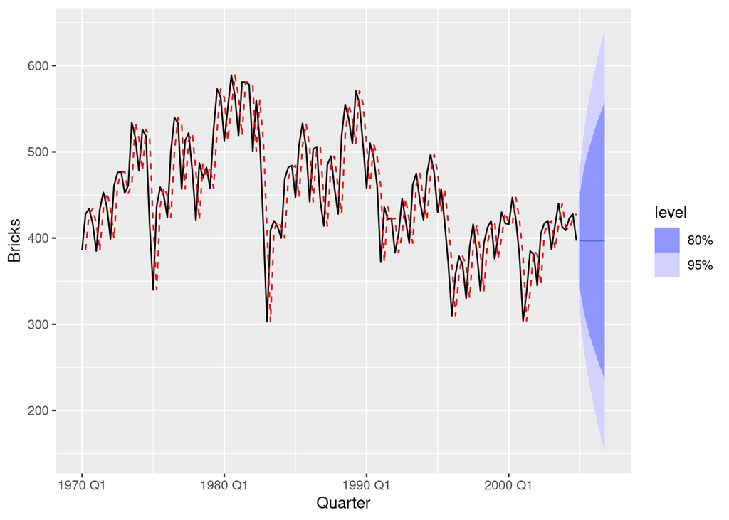

## Forecasts compared to fitted values - summary

The table below summarizes the comparison between the concepts of **fitted values vs. forecasts** that we explained in the previous section:

| Property | Forecasts - $\hat{y}_{T+h\|T}$ | Fitted values - $\hat{y}_{t\|t-1}$ |
| --- | --- | --- |
| Definition | Forecast at $T+h$ given everything that occurred up to $T$ | Fitted value at $t$ given everything that occurred up to $t-1$ |
| Range | Extend beyond the range of time of the training data (beyond $T$) | Limited to the time range corresponding to the training data ($t \leq T$) |
| Steps | Can be **multi-step**, that is, for a horizon $h>1$ | Are one-step ahead ($h=1$) |

**Note that** fitted values are strictly one-step ahead forecasts only when the model has no parameters estimated from the data. For most models the parameters were estimated using the whole training series, including $y_t$ (see the caveat above). The mean model is the most extreme example.

## Point Forecast and Forecast Distribution

To take a statistical approach to the forecasting task and account for uncertainty, it is best to consider a time series as a collection of random variables indexed by time. **A collection of random variables indexed by time is a type of stochastic process** (there are many possible structures for a stochastic process; a time series is just one of them).

- **Past values of the time series {${y_1, y_2, \dots, y_T}$}** are **random variables that have been realized**, that is, they have taken a specific outcome, a number, they have collapsed to a single value.
- **Future values of the time series**, the forecasts {$\hat{y}_{T+h|T}$}, are **random variables that have yet to be realized.**

Let us look at the following example of international arrivals to Australia, in which a model has been fitted and some forecasts have been produced:

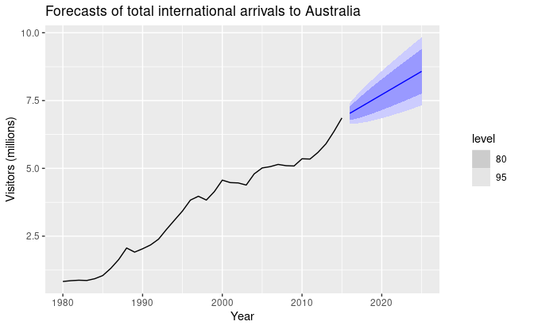

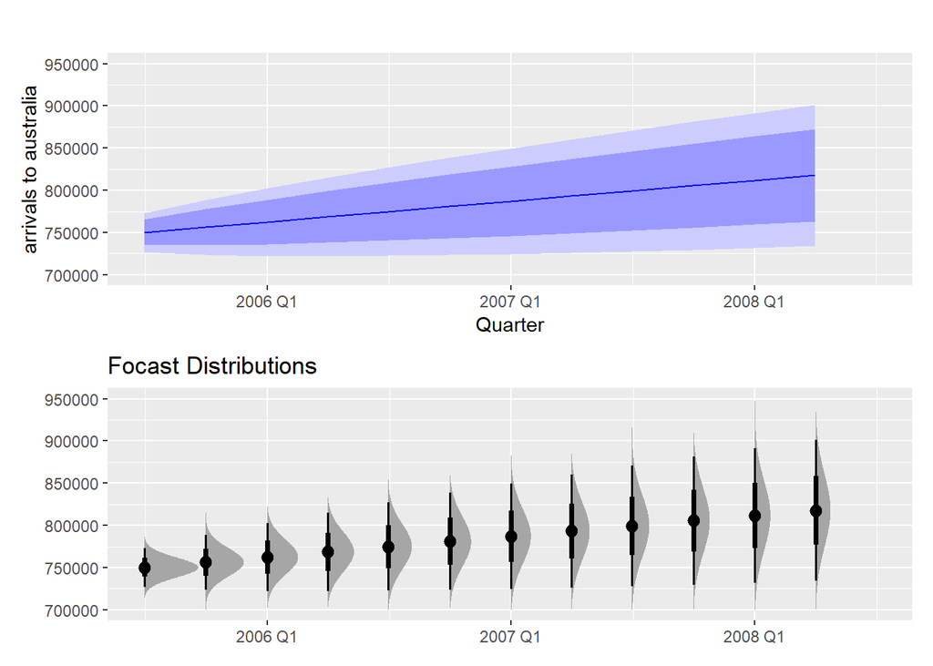

More technically, at each point $T+h$ in the future corresponding to the forecast region we have:

- $y_{T+h|T}$, the random variable at $T+h$ given the information available up to time $T$
- A **forecast distribution** associated with the random variable $y_{T+h|T}$ that describes the probability of occurrence of specific values.
- A **point forecast $\hat{y}_{T+h|T}$** that is the mean of the forecast distribution (the median is also used sometimes).

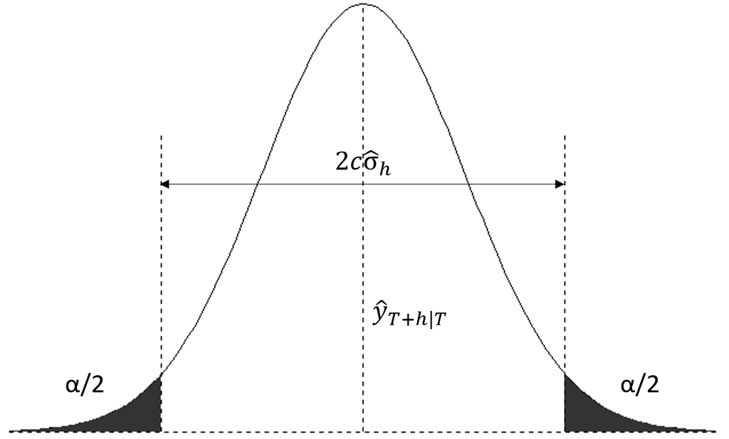

The most important concepts signaled here are:

- **Forecast distribution** as the probability density function describing the probabilities associated with the set of values that the forecast $y_{T+h|T}$ may take.
- **Point forecast $\hat{y}_{T+h|T}$** as the mean value of the forecast distribution.

As a side note, a collection of random variables {$y_t$} indexed by $t$ is a type of **stochastic process**.

# Residuals

The **residuals** are the **difference between the observations and the corresponding fitted values**. At a specific point $t$, the value of the residuals is:

$$e_{t} = y_{t}-\hat{y}_{t}.$$

## Innovation residuals

These are the residuals in the *transformed domain*, only relevant if a transformation has been used. If no transformation has been used, residuals and innovation residuals will match.

Let us look at an example. If we use a logarithmic transformation on the data:

- Original data: $y_t$
- Transformed data: $w_t = log(y_t)$

We would fit the model in the transformed domain, to our transformed data, hence generating

- Fitted values in the transformed domain: $\hat{w}_{t|t-1} \underset{\underset{\text{Simplified notation}}{\uparrow}}{=} \hat{w_t}$
- Residuals in the transformed domain (**innovation residuals**): $w_t - \hat{w_t}$

By reversing the transformation (backtransforming) we would obtain:

- Fitted values in the original domain: $\hat{y_t} = e^{\hat{w}_t}$
- Residuals in the original domain (**residuals**): $y_t - \hat{y_t}$

We will see later in this notebook that, in the `fpp3` library, we can obtain both the innovation residuals and the residuals using the function `augment()`.

# Mean model

Forecasts of all future values are equal to the average of the historical data.

$$\hat{y}_{T+h|T} = \bar{y} = (y_1 + y_2 + y_3 +\dots + y_{T})/T.$$

## Defining and training the model (generating the fitted values or *estimates*)

```r
fit <-
  bricks |>
  model(
    mean = MEAN(Bricks)
    )
fit
```

```
# A mable: 1 x 1
     mean
  <model>
1  <MEAN>
```

This particular mable (model table) has 1 row (1 time series fitted) and 1 column (1 model)

## Fitted values

The function `augment()` allows us to extract some relevant information contained within the model objects generated by the `fpp3` library. Among other things, fitted values and residuals. Note that the model also contains the original time series (column `Bricks`).

```r
fitted_vals <-
  fit |>
  augment()

head(fitted_vals)
```

```
# A tsibble: 6 x 6 [1Q]
# Key:       .model [1]
  .model Quarter Bricks .fitted .resid .innov
  <chr>    <qtr>  <dbl>   <dbl>  <dbl>  <dbl>
1 mean   1970 Q1    386    451.  -64.9  -64.9
2 mean   1970 Q2    428    451.  -22.9  -22.9
3 mean   1970 Q3    434    451.  -16.9  -16.9
4 mean   1970 Q4    417    451.  -33.9  -33.9
5 mean   1971 Q1    385    451.  -65.9  -65.9
6 mean   1971 Q2    433    451.  -17.9  -17.9
```

**The mean model is the most extreme example in which fitted values are not one-step-ahead forecasts on the training data**, because it uses data beyond the point at which the fitted value is computed.

- The fitted value at every point is computed using all the available data at $t=1, 2, 3, \cdots, T$, by computing the mean $(y_1 + y_2 + y_3 +\dots + y_{T})/T$.
- As an example, the fitted value at $t=3$ ($\hat{y}_{3|2}$) is not computed solely using $y_1$ and $y_2$, as the strict definition says, but rather using all the information from $t=1, 2, 3, \cdots, T$. Here the fitted value is nothing but the estimated parameter, so the model’s whole output depends on data from after $t$.

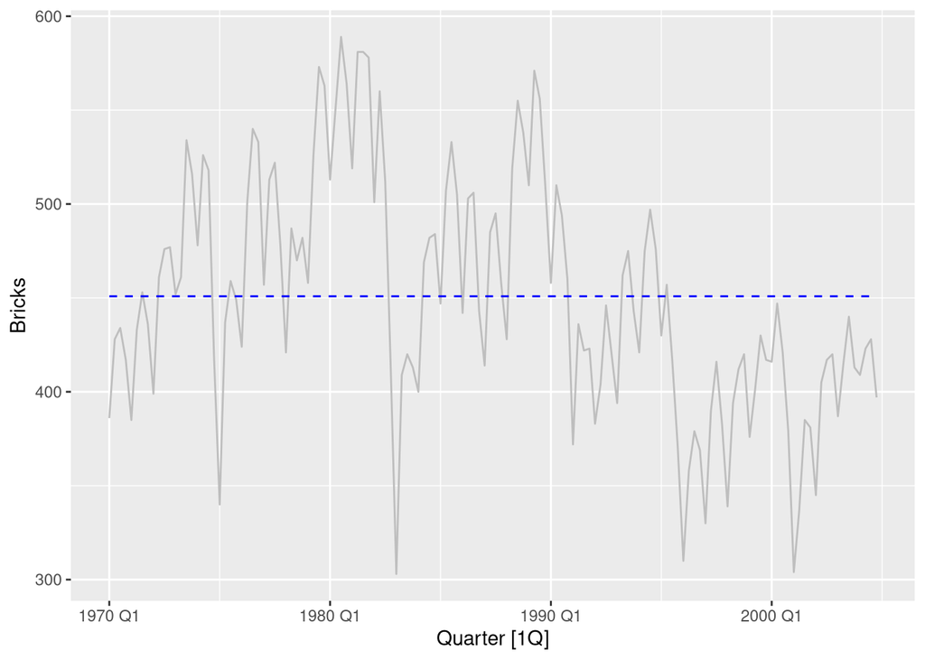

```r
fitted_vals |>
  filter(.model == "mean") |>
  autoplot(Bricks, colour = "gray") +
  geom_line(aes(y=.fitted), colour = "blue", linetype = "dashed")
```

## Forecasts

To produce forecasts in the `fable` library we use the `forecast()` function on the fitted model. We specify an argument: `h`, the number of time steps we wish to forecast.

```r
# produce forecasts for 8 timesteps
forecasts <- fit |> forecast(h = 8)
forecasts
```

```
# A fable: 8 x 4 [1Q]
# Key:     .model [1]
  .model Quarter
  <chr>    <qtr>
1 mean   2005 Q1
2 mean   2005 Q2
3 mean   2005 Q3
4 mean   2005 Q4
5 mean   2006 Q1
6 mean   2006 Q2
7 mean   2006 Q3
8 mean   2006 Q4
# ℹ 2 more variables: Bricks <dist>, .mean <dbl>
```

The output is a so-called **fable** (forecast table). Some comments about the result:

- The column `.mean` represents the forecast for each specific horizon $h=1, 2, \dots$. That is, the point forecast $\hat{y}_{T+h|T}$. The notation **`.mean`** is used because it refers to the **mean of the forecast distribution** as was explained earlier in this session.
- The column `Bricks` (or whatever the variable name is) in the resulting fable contains a distribution object detailing the forecast distribution at each forecast horizon.
  - For the case at hand we can see that these are normal distributions with $\mu =451$ and $\sigma^2 = 4022$.
  - We will see how to handle these distribution objects later in the course.

### Depicting forecasts along with the time series

**Important**: to depict the forecasts along with the time series, call `autoplot()` on the fable object (here, the variable `forecasts`) and pass the original tsibble object (here, `bricks`) as its argument. This depicts the forecasts alongside the original time series:

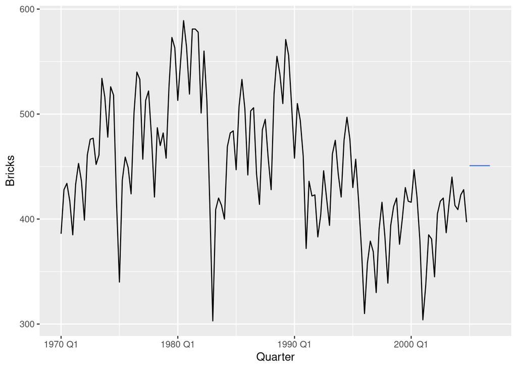

```r
# Depict the forecasts and the original series with autoplot()
forecasts |>

  # Depicts the original time series and the forecasts
  autoplot(bricks, level = NULL)
```

If you now wish to add the fitted values, you may use `geom_line()` to add another layer to the graph:

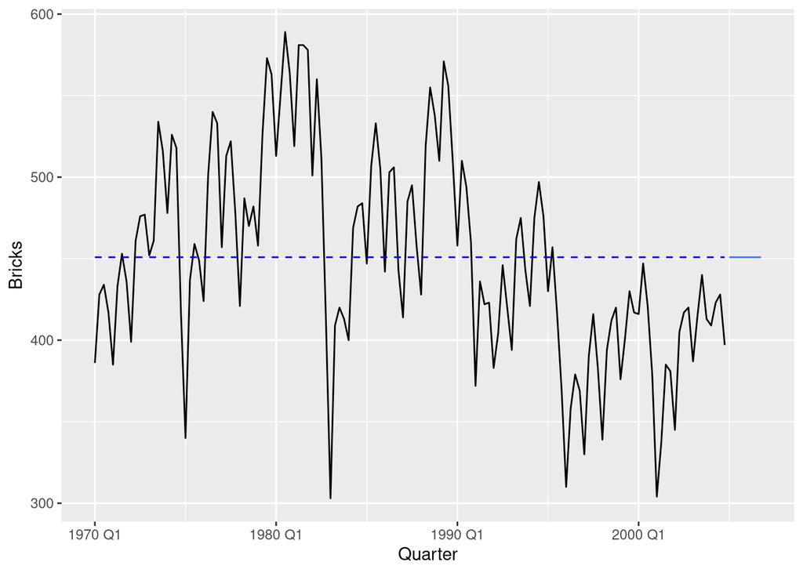

```r
# Depict the forecasts and the original series with autoplot()
forecasts |>

  # Depicts the original time series and the forecasts
  autoplot(bricks, level = NULL) +

  # Overlays the fitted values
  geom_line(data = fitted_vals, aes(y = .fitted), colour = "blue", linetype = "dashed")
```

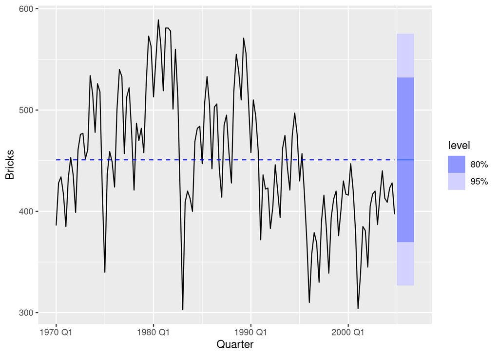

```r
# Depict the forecasts and the original series with autoplot(), including prediction intervals
forecasts |>

  # Depicts the original time series and the forecasts
  autoplot(bricks) +

  # Overlays the fitted values
  geom_line(data = fitted_vals, aes(y = .fitted), colour = "blue", linetype = "dashed")
```

## Estimates of the model parameters

Using the function `tidy()` on a fitted model, we can get the estimates of the parameters of the model. In this case there is only one parameter, the mean of the sample.

```r
tidy(fit)
```

```
# A tibble: 1 × 6
  .model term  estimate std.error statistic   p.value
  <chr>  <chr>    <dbl>     <dbl>     <dbl>     <dbl>
1 mean   mean      451.      5.34      84.4 2.58e-121
```

# Naïve model

The Naïve model sets all forecasts to be the value of the last available observation (observation at $t=T$)

$$\hat{y}_{T+h|T}=y_T$$

Let us use the `aus_exports` dataset to illustrate this with an example:

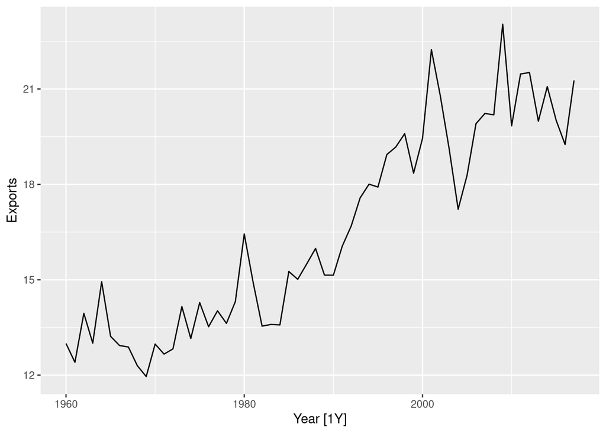

```r
aus_exports <- filter(global_economy, Country == "Australia")
autoplot(aus_exports, Exports)
```

## Defining and training the model (generating the fitted values or *estimates*)

```r
fit <- aus_exports |> model(Naive = NAIVE(Exports))
fit
```

```
# A mable: 1 x 2
# Key:     Country [1]
  Country     Naive
  <fct>     <model>
1 Australia <NAIVE>
```

Again the `mable` has 1 row (we are only fitting the model to 1 time series) and one column for the model (we only fitted one model).

## Fitted values

The naïve model produces the fitted values by calculating a **one step ahead forecast** using the previous observation.

Setting $h=1$ in the forecast equation of the Naive model, evaluated at $t+1$ instead of $T+1$ to remain in the training region, we obtain the equation for the fitted values:

$$\hat{y}_{t+1|t}=y_t$$

This gives us the fitted value at $t+1$. We want the fitted value at $t$, so we simply shift that equation one time-step to the past accordingly. Wherever we have $t$, we write $t-1$ and simplify, obtaining:

$$\hat{y}_{t|t-1}=y_{t-1}$$

This is the equation for the fitted value at $t$ in the case of the Naïve model. **The fitted value at $t$ is simply the observation at $t-1$.** Note that, as a result, **there will be no fitted value at $t=1$ for the Naïve model, since there is no previous value.**

Let us depict the fitted values for our example:

```r
# Extract fitted values and inspect table
fitted_vals <- fit |> augment()
head(fitted_vals)
```

```
# A tsibble: 6 x 7 [1Y]
# Key:       Country, .model [1]
  Country   .model  Year Exports .fitted .resid .innov
  <fct>     <chr>  <dbl>   <dbl>   <dbl>  <dbl>  <dbl>
1 Australia Naive   1960    13.0    NA   NA     NA
2 Australia Naive   1961    12.4    13.0 -0.591 -0.591
3 Australia Naive   1962    13.9    12.4  1.54   1.54
4 Australia Naive   1963    13.0    13.9 -0.937 -0.937
5 Australia Naive   1964    14.9    13.0  1.93   1.93
6 Australia Naive   1965    13.2    14.9 -1.72  -1.72
```

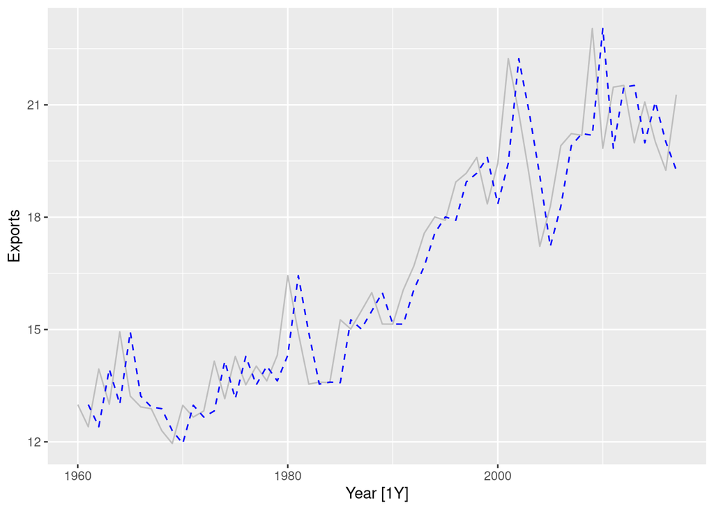

```r
# Print fitted values along with the original series
fitted_vals |>
  filter(.model == "Naive") |>
  autoplot(Exports, colour = "gray") +
  geom_line(aes(y=.fitted), colour = "blue", linetype = "dashed")
```

The above graph looks very similar to the first lag of the time series! In fact, that is exactly what it is.

## Forecasts

```r
# produce forecasts for 8 timesteps
forecasts <- fit |> forecast(h = 8)
forecasts
```

```
# A fable: 8 x 5 [1Y]
# Key:     Country, .model [1]
  Country   .model  Year
  <fct>     <chr>  <dbl>
1 Australia Naive   2018
2 Australia Naive   2019
3 Australia Naive   2020
4 Australia Naive   2021
5 Australia Naive   2022
6 Australia Naive   2023
7 Australia Naive   2024
8 Australia Naive   2025
# ℹ 2 more variables: Exports <dist>, .mean <dbl>
```

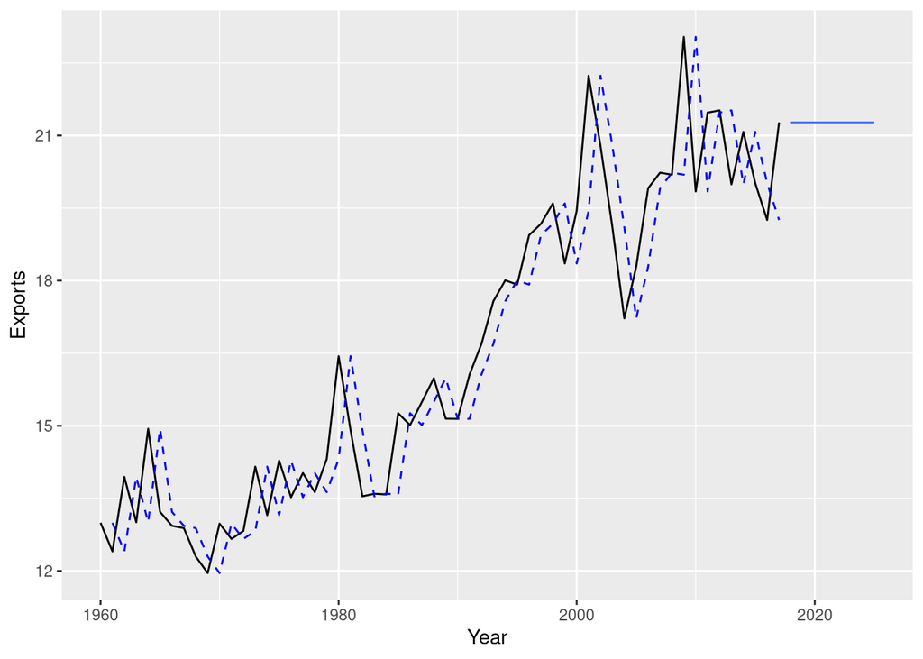

```r
# Depict the forecasts
forecasts |>
  autoplot(aus_exports, level = NULL) +

  # Overlays the fitted values
  geom_line(data = fitted_vals, aes(y = .fitted), colour = "blue", linetype = "dashed")
```

As previously explained, unlike the fitted values, the forecasts can extend multiple steps ahead into the future.

## Estimates of the model parameters

```r
tidy(fit)
```

```
# A tibble: 0 × 7
# ℹ 7 variables: Country <fct>, .model <chr>, term <chr>, estimate <dbl>,
#   std.error <dbl>, statistic <dbl>, p.value <dbl>
```

As we can see, **the Naïve model does not have any parameter**. It just forecasts by extending the last observation and does not need to estimate any parameter.

# Seasonal naïve

Each forecast is equal to the last observed value from the same season one season ago.

- For example: the same value of the series the same month of the previous year.

Formally, the *forecast at time T+h* is

$$\hat{y}_{T+h|T} = y_{T+h-m(k+1)}$$

where:

- $m$ is the seasonal period (length in timesteps of one season)
- $k$ is the integer part of $(h-1)/m$ (i.e., the number of complete years in the forecast period prior to time T + h).

The image below aims to clarify the meaning of $k$ in the formula for the forecasts with a specific example in which $m=12$ (monthly data, yearly seasonality):

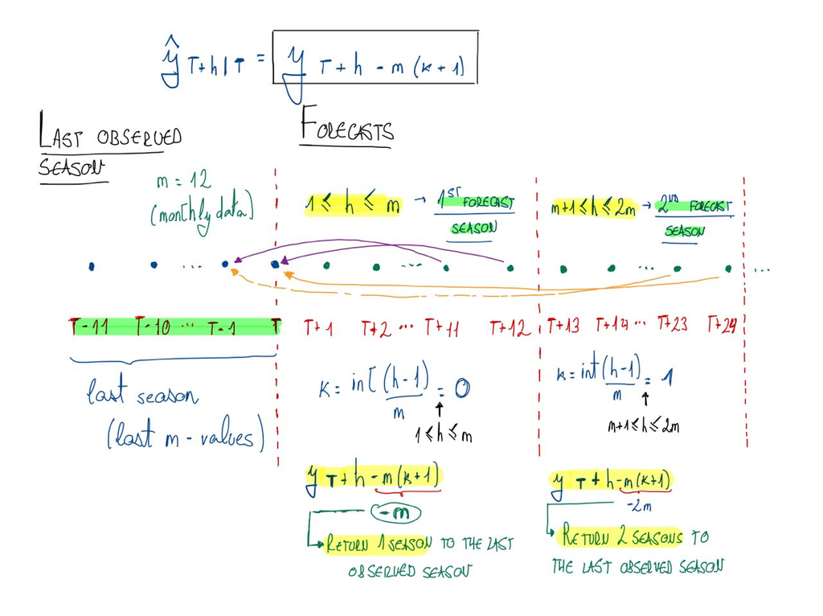

- **Example:** for monthly data ($m=12$)
  - $1 \leq h \leq 12$ (forecasts of up to one season ahead)
    - $0 \leq (h-1)/m < 1 \rightarrow k = int(\frac{h-1}{m}) = 0$.
    - Since $k=0 \rightarrow \hat{y}_{T+h|T}=y_{T+h-m(0+1)}=y_{T+h-m}$
    - i.e.: $\hat{y}_{T+h|T}=y_{T+h-m}$: the forecast is equal to the matching observation of the last available season in the historical data.
  - $13 \leq h \leq 24$ (forecasts of up to two seasons ahead)
    - $1 \leq (h-1)/m < 2 \rightarrow k = int(\frac{h-1}{m}) = 1$.
    - Since $k=1 \rightarrow \hat{y}_{T+h|T}=y_{T+h-m(1+1)}=y_{T+h-2m}$
    - i.e.: $\hat{y}_{T+h|T}=y_{T+h-2m}$: the forecast is equal to the matching observation of the last available season in the historical data.
  - $25 \leq h \leq 36$ (forecasts of up to three seasons ahead)
    - $2 \leq (h-1)/m < 3 \rightarrow k = int(\frac{h-1}{m}) = 2$.
    - Since $k=2 \rightarrow \hat{y}_{T+h|T}=y_{T+h-m(2+1)}=y_{T+h-3m}$
    - i.e.: $\hat{y}_{T+h|T}=y_{T+h-3m}$: the forecast is equal to the matching observation of the last available season in the historical data.
  - $37 \leq h \leq 48$ (forecasts of up to four seasons ahead)
    - …

The interpretation of the formula is therefore quite simple. In the case of monthly data:

- all future February values will be equal to the last observed February value.
- all future March values will be equal to the last observed March value.
- …

This will be **better understood with the examples below**.

Let us do an example with the `us_employment` series:

```r
employed <- filter(us_employment, Title == "Total Private", Month >= yearmonth("01-01-2010"))
head(employed)
```

```
# A tsibble: 6 x 4 [1M]
# Key:       Series_ID [1]
     Month Series_ID     Title         Employed
     <mth> <chr>         <chr>            <dbl>
1 2010 Jan CEU0500000001 Total Private   105444
2 2010 Feb CEU0500000001 Total Private   105490
3 2010 Mar CEU0500000001 Total Private   106176
4 2010 Apr CEU0500000001 Total Private   107220
5 2010 May CEU0500000001 Total Private   107931
6 2010 Jun CEU0500000001 Total Private   108710
```

```
Plot variable not specified, automatically selected `.vars = Employed`
```

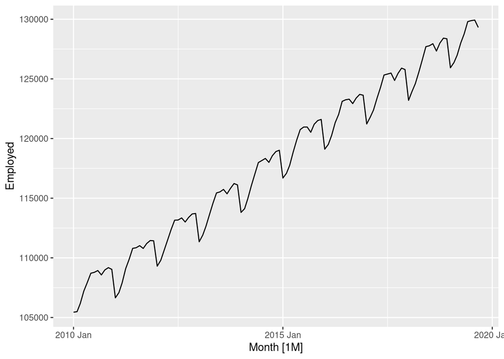

```r
autoplot(employed)
```

## Defining and training the model

```r
fit <- employed |> model(SNaive = SNAIVE(Employed))
fit
```

```
# A mable: 1 x 2
# Key:     Series_ID [1]
  Series_ID       SNaive
  <chr>          <model>
1 CEU0500000001 <SNAIVE>
```

**NOTE**: we may use the special argument `lag` to specify the seasonal period the method is to consider. Most of the time this is not necessary, but in case there are multiple possible seasonal periods, you may want to specify which specifically you want SNAIVE() to consider.

```r
# In this case it is not necessary to specify lag
fit <- employed |> model(SNaive = SNAIVE(Employed ~ lag("year")))
fit
```

```
# A mable: 1 x 2
# Key:     Series_ID [1]
  Series_ID       SNaive
  <chr>          <model>
1 CEU0500000001 <SNAIVE>
```

## Fitted values

Because the method generates forecasts by using the corresponding observation from the previous season, the model does not generate fitted values for the first season (remember fitted values are one-step ahead forecasts):

```r
# Extract fitted values and inspect table
fitted_vals <- fit |> augment()
head(fitted_vals)
```

```
# A tsibble: 6 x 7 [1M]
# Key:       Series_ID, .model [1]
  Series_ID     .model    Month Employed .fitted .resid .innov
  <chr>         <chr>     <mth>    <dbl>   <dbl>  <dbl>  <dbl>
1 CEU0500000001 SNaive 2010 Jan   105444      NA     NA     NA
2 CEU0500000001 SNaive 2010 Feb   105490      NA     NA     NA
3 CEU0500000001 SNaive 2010 Mar   106176      NA     NA     NA
4 CEU0500000001 SNaive 2010 Apr   107220      NA     NA     NA
5 CEU0500000001 SNaive 2010 May   107931      NA     NA     NA
6 CEU0500000001 SNaive 2010 Jun   108710      NA     NA     NA
```

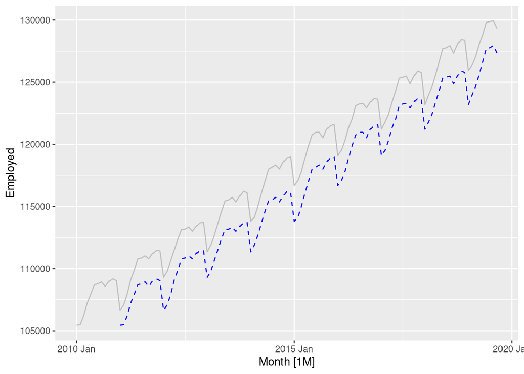

```r
# Print fitted values along with the original series
fitted_vals |>
  filter(.model == "SNaive") |>
  autoplot(Employed, colour = "gray") +
  geom_line(aes(y=.fitted), colour = "blue", linetype = "dashed")
```

## Forecasts

```r
# produce forecasts for 36 timesteps
forecasts <- fit |> forecast(h = 36)
forecasts
```

```
# A fable: 36 x 5 [1M]
# Key:     Series_ID, .model [1]
   Series_ID     .model    Month
   <chr>         <chr>     <mth>
 1 CEU0500000001 SNaive 2019 Oct
 2 CEU0500000001 SNaive 2019 Nov
 3 CEU0500000001 SNaive 2019 Dec
 4 CEU0500000001 SNaive 2020 Jan
 5 CEU0500000001 SNaive 2020 Feb
 6 CEU0500000001 SNaive 2020 Mar
 7 CEU0500000001 SNaive 2020 Apr
 8 CEU0500000001 SNaive 2020 May
 9 CEU0500000001 SNaive 2020 Jun
10 CEU0500000001 SNaive 2020 Jul
# ℹ 26 more rows
# ℹ 2 more variables: Employed <dist>, .mean <dbl>
```

```
Warning: Removed 12 rows containing missing values or values outside the scale range
(`geom_line()`).
```

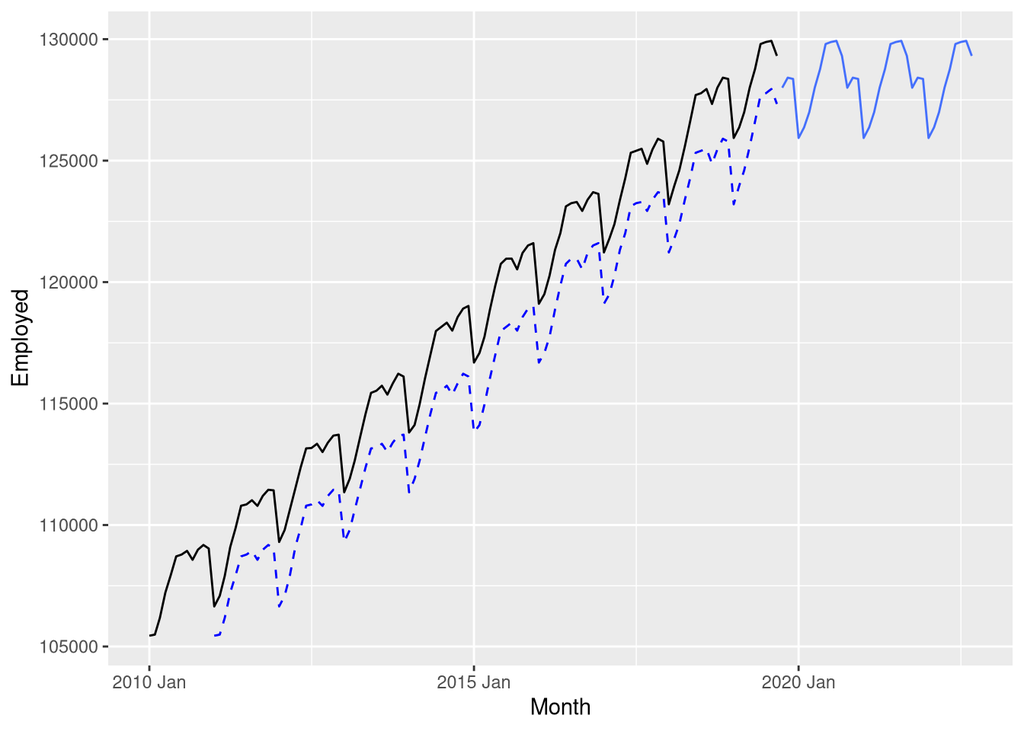

```r
# Depict the forecasts
forecasts |>
  autoplot(employed, level = NULL) +
  autolayer(fitted_vals, .fitted, colour = "blue", linetype = "dashed")
```

The warning about removed rows is expected: those are the twelve months of the first season, which have no fitted value.

## What the seasonal naïve method misses

The forecasts repeat the last observed year, so they carry the seasonal pattern forward but **no trend**. This series grows steadily, so the forecasts fall further behind the actual values with every year of the horizon.

The same problem is visible in the past. Each fitted value is the observation from one year earlier, so the dashed line sits below the series by roughly one year of growth. The residuals are therefore positive, every one of them:

```r
fitted_vals |>
  as_tibble() |>
  summarise(
    mean_resid = mean(.resid, na.rm = TRUE),
    share_positive = mean(.resid > 0, na.rm = TRUE)
  )
```

```
# A tibble: 1 × 2
  mean_resid share_positive
       <dbl>          <dbl>
1      2336.              1
```

Good residuals have a mean close to zero. A mean this far from zero means the method is **biased**: on this series it underforecasts systematically. The seasonal naïve method works well on a seasonal series with no trend. On a trending one it needs help, which is what the drift method and forecasting with decomposition, below, provide.

## Estimates of the model parameters

```r
tidy(fit)
```

```
# A tibble: 0 × 7
# ℹ 7 variables: Series_ID <chr>, .model <chr>, term <chr>, estimate <dbl>,
#   std.error <dbl>, statistic <dbl>, p.value <dbl>
```

As we can see, the seasonal naïve model, just like the naïve model, does not have any parameters

# Drift method

The drift method allows forecasts to increase or decrease over time, with the **forecasts increasing by a specific constant called the drift for every unit of time**.

- The **drift** is the amount of change per unit time, set to be the **average change in the historical data**.

That **average change in the historical data** will in the end be the **slope of the line joining the first and last point in the training data**. The figures below explain this in more detail:

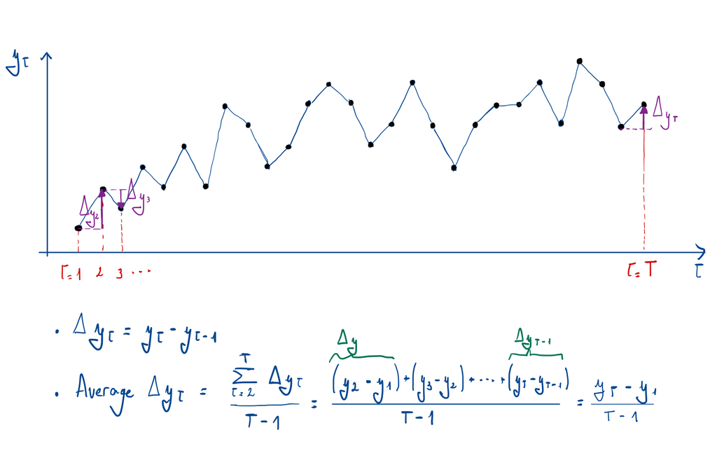

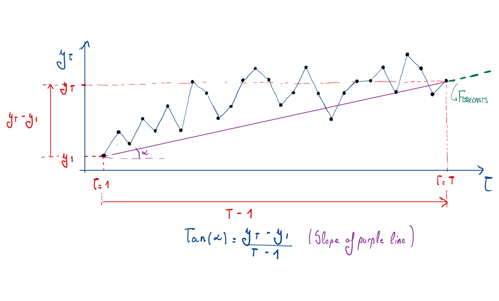

The drift method extrapolates this average change into the future to compute $\hat{y}_{T+h|T}$ by simply multiplying this average change by $h$. In other words, it creates a straight line covering the entire forecast horizon with a slope equal to the average change. Mathematically, it works as follows:

If $\Delta y_t = y_t - y_{t-1}$ then the equation for the drift method may be written as:

$$\begin{equation}
\hat{y}_{T+h|T} = y_{T} + h \underbrace{\frac{\sum_{t=2}^{t=T}\Delta y_t}{T-1}}_{\substack{\text{average change of } y \\ \text{in the historical data}}} = y_{T} + h \ \frac{\sum_{t=2}^{t=T} (y_{t}-y_{t-1})}{{T-1}} = y_{T} + h \left( \frac{y_{T} -y_{1}}{T-1}\right)
\end{equation}$$

## Defining and training the model

- NOTE: RW stands for *Random Walk*. More about this later in the course, in the context of ARIMA models.

```r
fit <- employed |> model(Drift = RW(Employed ~ drift()))
fit
```

```
# A mable: 1 x 2
# Key:     Series_ID [1]
  Series_ID             Drift
  <chr>               <model>
1 CEU0500000001 <RW w/ drift>
```

**Equivalent to drawing a line between the first and last observations and extrapolating into the future** (the final graph of the example clarifies this further).

## Fitted values

```r
# Extract fitted values and inspect table
fitted_vals <- fit |> augment()
head(fitted_vals)
```

```
# A tsibble: 6 x 7 [1M]
# Key:       Series_ID, .model [1]
  Series_ID     .model    Month Employed .fitted .resid .innov
  <chr>         <chr>     <mth>    <dbl>   <dbl>  <dbl>  <dbl>
1 CEU0500000001 Drift  2010 Jan   105444     NA     NA     NA
2 CEU0500000001 Drift  2010 Feb   105490 105650.  -160.  -160.
3 CEU0500000001 Drift  2010 Mar   106176 105696.   480.   480.
4 CEU0500000001 Drift  2010 Apr   107220 106382.   838.   838.
5 CEU0500000001 Drift  2010 May   107931 107426.   505.   505.
6 CEU0500000001 Drift  2010 Jun   108710 108137.   573.   573.
```

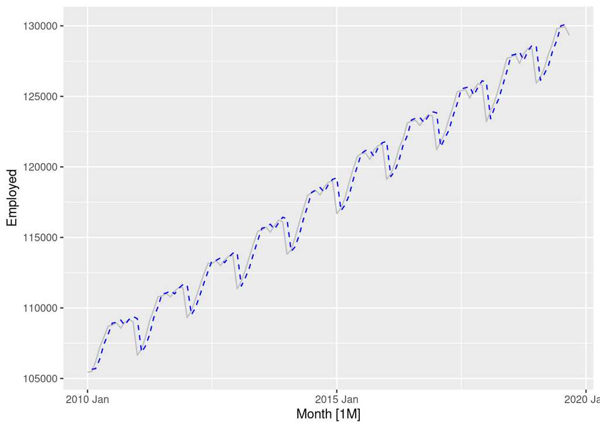

```r
# Print fitted values along with the original series
fitted_vals |>
  filter(.model == "Drift") |>
  autoplot(Employed, colour = "gray") +
  geom_line(aes(y=.fitted), colour = "blue", linetype = "dashed")
```

## Forecasts

```r
forecasts <- fit |> forecast(h=8)
forecasts
```

```
# A fable: 8 x 5 [1M]
# Key:     Series_ID, .model [1]
  Series_ID     .model    Month
  <chr>         <chr>     <mth>
1 CEU0500000001 Drift  2019 Oct
2 CEU0500000001 Drift  2019 Nov
3 CEU0500000001 Drift  2019 Dec
4 CEU0500000001 Drift  2020 Jan
5 CEU0500000001 Drift  2020 Feb
6 CEU0500000001 Drift  2020 Mar
7 CEU0500000001 Drift  2020 Apr
8 CEU0500000001 Drift  2020 May
# ℹ 2 more variables: Employed <dist>, .mean <dbl>
```

```r
# Extract the initial and final points of the series
# to depict the average change slope.
n_rows = nrow(employed)
drift_points <- tibble(Month = c(employed$Month[1], employed$Month[n_rows]),
                       Employed = c(employed$Employed[1], employed$Employed[n_rows])) |>
                as_tsibble()
```

```
Using `Month` as index variable.
```

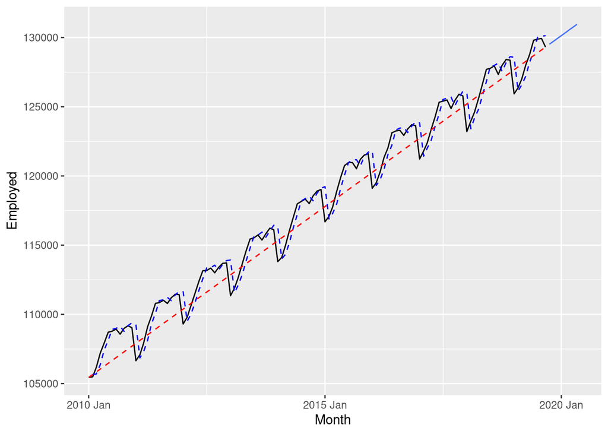

```r
# Depict the forecasts
forecasts |>
  autoplot(employed, level = NULL) +
  autolayer(fitted_vals, .fitted, colour = "blue", linetype = "dashed") +
  geom_line(drift_points, mapping = aes(x = Month, y = Employed), color = "red", linetype = "dashed")
```

In the above graph we can see that:

1. The forecasts are generated following the slope of the line that connects the initial and final points of the series (the red dashed line). A further example is depicted in the image below:

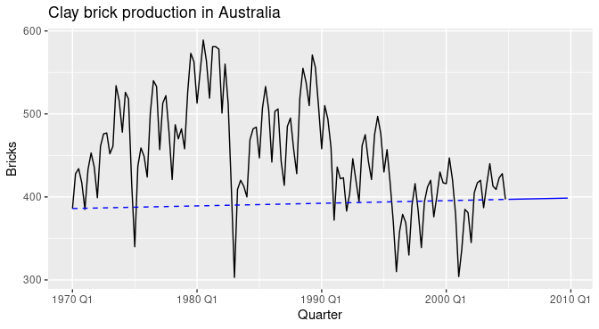

Further example of the drift method. From [1]

2. The fitted values are very similar to those of the Naïve Method. Nonetheless, they are not the same. In this case each fitted value is generated by a one-step forecast using the drift method. That is, the previous observation moved one step along the drift slope, the slope of the line joining the first and last observations of the training data. Because that slope is computed using $y_T$, these fitted values are one-step forecasts in form but not true forecasts: every fitted value uses the last observation of the series.

## Estimates of the model parameters

We can look at the number of parameters in a model and their values using the function `tidy()`. If we apply it to the drift model we get:

```r
tidy(fit)
```

```
# A tibble: 1 × 7
  Series_ID     .model term  estimate std.error statistic p.value
  <chr>         <chr>  <chr>    <dbl>     <dbl>     <dbl>   <dbl>
1 CEU0500000001 Drift  b         206.      80.8      2.54  0.0123
```

The drift model has only one parameter, the slope of the line joining the first and the last observation.

# Forecasting with decomposition

If an appropriate decomposition algorithm for the time series has been found, then it is often of interest to build two separate models:

1. A model for the seasonally adjusted component
2. A model for the seasonal component.

Afterwards the forecasts of both models may be combined to yield the final forecast.

Recall that, if the seasonal component is $\hat{S_t}$, the **seasonally adjusted component $\hat{A_t}$ of the time series** is what results from removing the effect of seasonality from the time series.

The seasonally adjusted component is computed differently depending on whether the scheme is additive or multiplicative:

$$\begin{align*}
\text{For additive schemes} && \hat{A_t} = y_t - \hat{S_t} \\
\text{For multiplicative schemes} && \hat{A_t} = \frac{y_t}{\hat{S_t}} \\
\end{align*}$$

The decomposed series can be written as:

- $y_t = \hat{S}_t + \hat{A}_t$ for additive schemes
  - where $\hat{A}_t = \hat{T}_t+\hat{R}_{t}$ is the seasonally adjusted component.
- $y_t = \hat{S}_t\hat{A}_t$ for multiplicative schemes
  - where $\hat{A}_t = \hat{T}_t\hat{R}_{t}$ is the seasonally adjusted component.

To forecast a decomposed time series, $\hat{S_t}$ and $\hat{A_t}$ are forecast separately:

- $\hat{A_t}$: any non-seasonal forecasting method may be used (drift method, Holt’s method, ARIMA)…
- $\hat{S_t}$: usually assumed to remain unchanged, or to change very slowly. Often it is forecast by taking the observations of the last season, that is, using simply a seasonal naïve model.

In the `fpp3` library, we do all of the above with the function `decomposition_model()`. Below is a summary image of what this function does:

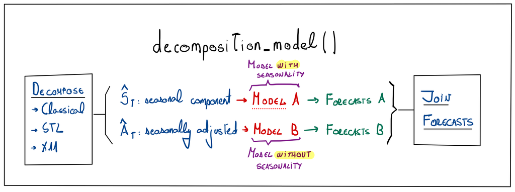

## Fitting the model

Let us use the `employed` time series again:

```
Plot variable not specified, automatically selected `.vars = Employed`
```

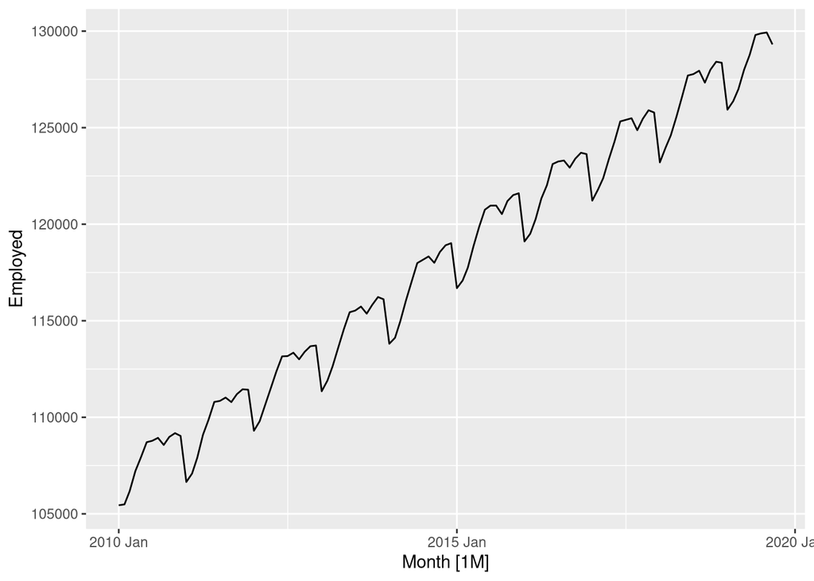

```r
employed <- filter(us_employment, Title == "Total Private", Month >= yearmonth("01-01-2010"))
autoplot(employed)
```

To fully understand the model specification, let us first look at the outcome of an STL decomposition applied to this series

```r
employed |>
  model(
    stl = STL(Employed)
  ) |>
  components()
```

```
# A dable: 117 x 8 [1M]
# Key:     Series_ID, .model [1]
# :        Employed = trend + season_year + remainder
   Series_ID .model    Month Employed  trend season_year remainder season_adjust
   <chr>     <chr>     <mth>    <dbl>  <dbl>       <dbl>     <dbl>         <dbl>
 1 CEU05000… stl    2010 Jan   105444 1.07e5      -2016.    272.         107460.
 2 CEU05000… stl    2010 Feb   105490 1.07e5      -1816.     -8.49       107306.
 3 CEU05000… stl    2010 Mar   106176 1.07e5      -1231.    -33.0        107407.
 4 CEU05000… stl    2010 Apr   107220 1.08e5       -361.     14.7        107581.
 5 CEU05000… stl    2010 May   107931 1.08e5        305.    -69.4        107626.
 6 CEU05000… stl    2010 Jun   108710 1.08e5       1006.   -121.         107704.
 7 CEU05000… stl    2010 Jul   108784 1.08e5        916.    -85.9        107868.
 8 CEU05000… stl    2010 Aug   108936 1.08e5        886.    -36.8        108050.
 9 CEU05000… stl    2010 Sep   108568 1.08e5        357.     -9.10       108211.
10 CEU05000… stl    2010 Oct   108984 1.08e5        648.    -17.2        108336.
# ℹ 107 more rows
```

The seasonal component is stored in a column named `season_year` and the seasonally adjusted component is stored in a column named `season_adjust`. To fully specify `decomposition_model()` we need to:

- Specify a decomposition scheme
- Provide a model for the seasonally adjusted component.
- Provide a model for the seasonal component (by default the SNAIVE component is used, so this is not strictly necessary).

```r
fit <- employed |>
  model(
    decomp = decomposition_model(

                # 1. Specify the decomposition scheme to be used.
                #    You may specify the windows of STL or other arguments for
                #.   the decomposition method of your choice
                STL(Employed),

                # 2. Specify a model for the seasonally adjusted component
                #.   A model with no seasonality is to be used. In this case, a drift.
                #.   season_adjust is the name of the seasonally adjusted component
                #.   resulting from applying the STL decomposition. This name could be
                #.   slightly different in other methods, so beware.
                RW(season_adjust ~ drift()),

                # 3. Specify a model for the seasonal component (SNAIVE is the default).
                #    A model with seasonality is to be used.
                #.   season_year is the name of the seasonal component resulting
                #.   from applying the STL decomposition. This name could be slightly
                #.   different in other methods, so beware.
                SNAIVE(season_year)
            )
  )

fit
```

```
# A mable: 1 x 2
# Key:     Series_ID [1]
  Series_ID                        decomp
  <chr>                           <model>
1 CEU0500000001 <STL decomposition model>
```

## Fitted values

As usual, you can extract the fitted values using `augment()`:

```r
fit |> augment()
```

```
# A tsibble: 117 x 7 [1M]
# Key:       Series_ID, .model [1]
   Series_ID     .model    Month Employed .fitted .resid .innov
   <chr>         <chr>     <mth>    <dbl>   <dbl>  <dbl>  <dbl>
 1 CEU0500000001 decomp 2010 Jan   105444      NA     NA     NA
 2 CEU0500000001 decomp 2010 Feb   105490      NA     NA     NA
 3 CEU0500000001 decomp 2010 Mar   106176      NA     NA     NA
 4 CEU0500000001 decomp 2010 Apr   107220      NA     NA     NA
 5 CEU0500000001 decomp 2010 May   107931      NA     NA     NA
 6 CEU0500000001 decomp 2010 Jun   108710      NA     NA     NA
 7 CEU0500000001 decomp 2010 Jul   108784      NA     NA     NA
 8 CEU0500000001 decomp 2010 Aug   108936      NA     NA     NA
 9 CEU0500000001 decomp 2010 Sep   108568      NA     NA     NA
10 CEU0500000001 decomp 2010 Oct   108984      NA     NA     NA
# ℹ 107 more rows
```

**QUESTION**: Why are the first rows of the fitted values NA?

## Forecasts

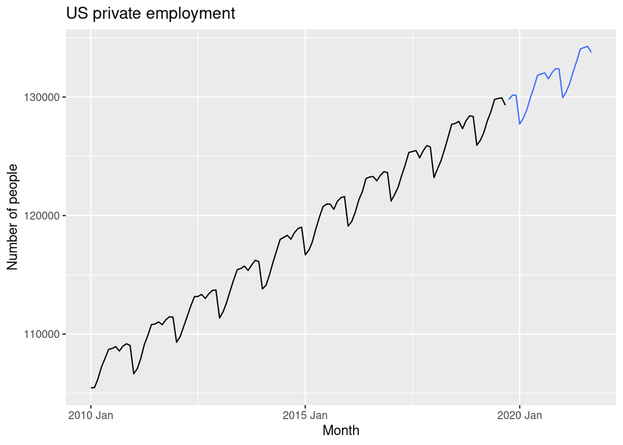

```r
fit |>
  forecast() |>
  autoplot(employed, level = NULL) +
  labs(y = "Number of people",
       title = "US private employment")
```

```r
fit
```

```
# A mable: 1 x 2
# Key:     Series_ID [1]
  Series_ID                        decomp
  <chr>                           <model>
1 CEU0500000001 <STL decomposition model>
```

The graph above shows that the model combines the SNAIVE + the DRIFT forecasts (this is equivalent to adding the slope of the drift model to the seasonal naive model).

## Estimates of the model parameters

When using the function `tidy()` on the decomposition model, we get the following error:

`no applicable method for 'tidy' applied to an object of class "c('decomposition_model', 'model_combination')`

```r
tidy(fit)
```

```
Error in `mutate()`:
ℹ In argument: `dplyr::across(all_of(mbl_vars), tidy)`.
Caused by error in `across()`:
! Can't compute column `decomp`.
Caused by error in `UseMethod()`:
! no applicable method for 'tidy' applied to an object of class "c('decomposition_model', 'model_combination')"
```

What this means is that `decomposition_model` is actually the combination of two models and the function `tidy()` is not programmed to deal with this. To get estimates of the model parameters, we should perform the decomposition of the model as defined and then fit the models separately to the seasonally adjusted component and the seasonal component. Inspecting each of those objects would yield the model estimates.

```r
# Create the decomposition model
dcmp <-
  employed |>
  model(
    stl = STL(Employed)
  ) |>
  components()

# Model for the seasonally adjusted data.
# Note that season_adjust is a column within dcmp
fit_seasonadj <-
  dcmp |>
  select(season_adjust) |>
  model(
    drift = RW(season_adjust ~ drift())
  )

# Model for the seasonal data.
# Note that season_year is a column within dcmp
fit_seasonal <-
  dcmp |>
  select(season_year) |>
  model(
    snaive = SNAIVE(season_year)
  )

# Parameters of drift model
tidy(fit_seasonadj)
```

```
# A tibble: 1 × 6
  .model term  estimate std.error statistic  p.value
  <chr>  <chr>    <dbl>     <dbl>     <dbl>    <dbl>
1 drift  b         186.      8.66      21.5 4.48e-42
```

```r
# Estimates of parameters for snaive model
tidy(fit_seasonal)
```

```
# A tibble: 0 × 6
# ℹ 6 variables: .model <chr>, term <chr>, estimate <dbl>, std.error <dbl>,
#   statistic <dbl>, p.value <dbl>
```

# Exercise 1

For this exercise we are going to use the `aus_retail` dataset. Remember you can always use `?aus_retail` in the console to read the details about the dataset.

The dataset contains a variety of series that can be filtered using their specific series ID. We will work with the following Series ID: A3349767W. The following code filters the series for you.

```r
retail_series <- aus_retail |>
  filter(`Series ID` == "A3349767W")

head(retail_series)
```

```
# A tsibble: 6 x 5 [1M]
# Key:       State, Industry [1]
  State              Industry                      `Series ID`    Month Turnover
  <chr>              <chr>                         <chr>          <mth>    <dbl>
1 Northern Territory Clothing, footwear and perso… A3349767W   1988 Apr      2.3
2 Northern Territory Clothing, footwear and perso… A3349767W   1988 May      2.9
3 Northern Territory Clothing, footwear and perso… A3349767W   1988 Jun      2.6
4 Northern Territory Clothing, footwear and perso… A3349767W   1988 Jul      2.8
5 Northern Territory Clothing, footwear and perso… A3349767W   1988 Aug      2.9
6 Northern Territory Clothing, footwear and perso… A3349767W   1988 Sep      3
```

## 1. STL decomposition (solved)

Use an STL decomposition to calculate the trend-cycle and seasonal indices. Adjust the trend and season windows if you deem it necessary.

**NOTE:** remember that the STL decomposition is only applicable to additive schemes, which means you need to transform the data first to obtain an additive scheme. To pick the best transformation, I am going to use the `guerrero` feature, something we will see in the following session. For now take this analysis as a given (I leave it here so you can revisit it later):

```
Plot variable not specified, automatically selected `.vars = Turnover`
```

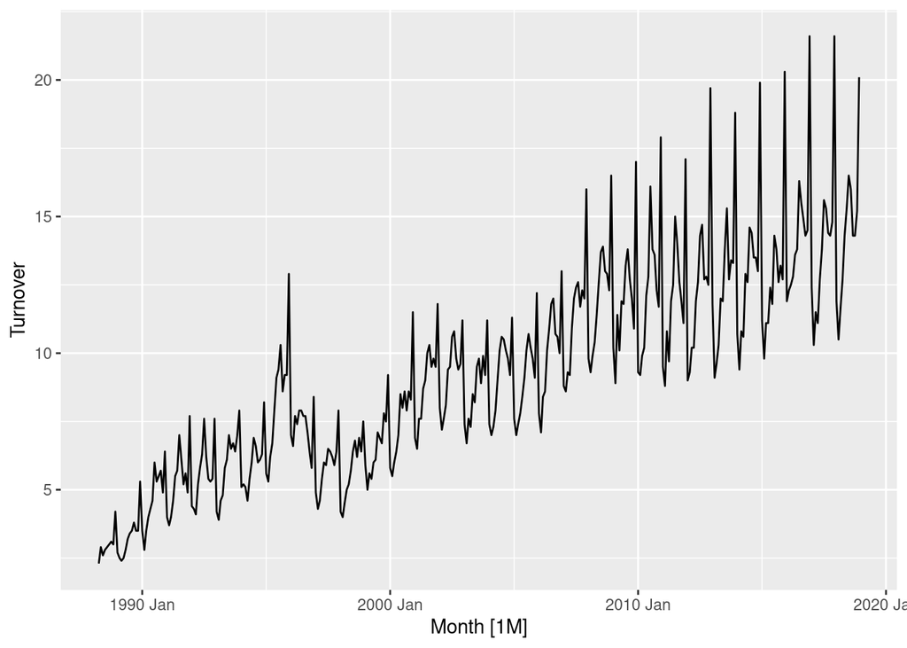

```r
retail_series |> autoplot()
```

```r
# let us examine the guerrero feature to see which Box-Cox transformation would
# be more appropriate.
lambda <- retail_series |>
  features(Turnover, features = guerrero) |>
  pull(lambda_guerrero)

lambda
```

```
[1] 0.08303631
```

This means that a log transformation should be applied. In this particular case we are not going to adjust the STL windows. We are going to **specify the log transformation within the model formula**. We will see later that this is important.

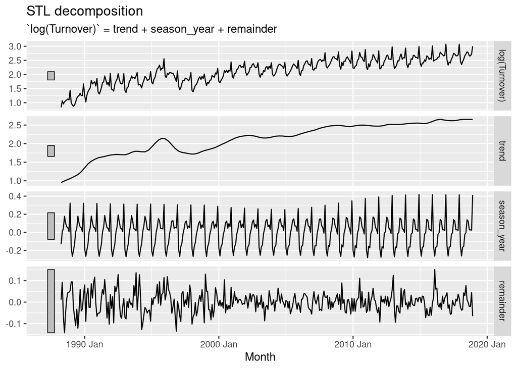

```r
dcmp <- retail_series |>
        model(stl = STL(log(Turnover))) |>
        components()

dcmp |> autoplot()
```

With this decomposition in place, carry out the rest of the exercise.

## 2. Extract the seasonally adjusted data

Extract the seasonally adjusted data from `dcmp` using `select` and store it in a separate tsibble called `season_adjust`. Plot the seasonally adjusted data.

## 3. Forecast the seasonally adjusted data with the drift method

Use the drift method to produce forecasts of the seasonally adjusted data. Generate a graph with the time series, the fitted values, and the forecasts.

## 4. Forecast the seasonal component with SNAIVE

Extract the seasonal component from `dcmp` using `select` and store it in a separate tsibble called `seasonal`. Use the SNAIVE method to produce forecasts of the seasonal component. Generate a graph with the time series, the fitted values, and the forecasts.

## 5. Combine both models with `decomposition_model()`

Use `decomposition_model()` on the original time series. Use the drift method for the seasonally adjusted data and the seasonal naïve method for the seasonal component.